# Pooling effect sizes in R

Practical · Wednesday 14:25–15:00 · FRB-CESAB training course

Author

Damien Beillouin

**By the end of this practical, you will be able to**

1. Fit **common-effect**, **random-effects** and **multilevel** models with `metafor`, and compare their **weights** and **confidence intervals**.
2. Report **τ², I²** and the **prediction interval**.
3. Add a **robust** (cluster-robust) safety net.
4. Draw an **orchard plot**.

[output not shown]

Sections marked *(optional)* are for those who are ahead: skip them if you are short of time.

# 1 Setup

Open `meta_analysis_course.Rproj` (the course kit), then `td_models.R` (it contains every exercise with blanks `___`). Same data and same effect sizes as this morning: **pest abundance, intercropping vs monoculture**. As announced this morning, comparisons with a zero mean or no usable SD are **set aside** (`!sd_missing, !zero_mean`) — in a real review, report how many and test the conclusion with imputed SDs.

```r
library(dplyr)
library(metafor)
library(ggplot2)

# In the participant pack: data_file <- "intercropping_biodiversity.csv"
ic <- read.csv(data_file)

grp <- "Pests"        # <- in section 6 you will change this word only

sub <- ic |>
  filter(functional_group == grp, !sd_missing, !zero_mean)

dat <- escalc(measure = "ROM",
              m1i = b_mean_t, sd1i = b_sd_t, n1i = b_n_t,
              m2i = b_mean_c, sd2i = b_sd_c, n2i = b_n_c,
              data = sub)

c(comparisons = nrow(dat), studies = n_distinct(dat$study_id))
```

```
comparisons     studies
        382          28
```

A small helper to turn lnRR into a % change:

```r
pct <- function(x) round(100 * (exp(x) - 1), 1)
```

# 2 Common vs random effects

**Exercise 1.** Fit a common-effect model (`method = "EE"`) and a random-effects model (default estimator REML). `test = "knha"` (Knapp–Hartung) widens the CI slightly to account for the uncertainty in τ² — recommended. Compare the estimates and CIs in %.

```r
m_ee <- rma(yi, vi, data = dat, method = "___")
m_re <- rma(yi, vi, data = dat, test = "knha")

pct(c(m_ee$b, m_ee$ci.lb, m_ee$ci.ub))
pct(c(m_re$b, ___, ___))
```

**Solution**

```r
m_ee <- rma(yi, vi, data = dat, method = "EE")
m_re <- rma(yi, vi, data = dat, test = "knha")

pct(c(m_ee$b, m_ee$ci.lb, m_ee$ci.ub))
```

```
[1] -17.2 -17.3 -17.0
```

```r
pct(c(m_re$b, m_re$ci.lb, m_re$ci.ub))
```

```
[1] -27.7 -32.7 -22.3
```

**Exercise 2.** Which study dominates? Compute the share of the total weight taken by each study in both models.

```r
w_ee <- 1 / dat$vi
w_re <- 1 / (dat$vi + m_re$___)

share <- function(w) sort(round(100 * tapply(w, dat$study_id, sum) / sum(w), 1), decreasing = TRUE)
head(share(w_ee), 3)
head(share(w_re), 3)
```

**Solution**

```r
w_ee <- 1 / dat$vi
w_re <- 1 / (dat$vi + m_re$tau2)

share <- function(w) sort(round(100 * tapply(w, dat$study_id, sum) / sum(w), 1), decreasing = TRUE)
head(share(w_ee), 3)
```

```
 525  645  520
76.0 22.8  0.5
```

```r
head(share(w_re), 3)
```

```
 645  525  740
26.2 16.9  6.5
```

In the common-effect model, **two studies carry almost all the weight** (study 525, Zhou et al. 2013, and study 645, Maluleke et al. 2005). In the random-effects model the weights are more equal — but study 645, which has 80 comparisons, now counts for about a quarter of the result **because it has many rows**. That is the non-independence problem of section 4.

Look at `dat[dat$study_id == 525, c("b_mean_t", "b_mean_c", "b_n_t", "vi")]`: n = 100 subsamples and the **same treatment means reused** against several controls give tiny variances. Always inspect your smallest variances — they may reveal pseudo-replication at extraction.

# 3 Heterogeneity and prediction interval

```r
m_re
```

```
Random-Effects Model (k = 382; tau^2 estimator: REML)

tau^2 (estimated amount of total heterogeneity): 0.3386 (SE = 0.0296)
tau (square root of estimated tau^2 value):      0.5819
I^2 (total heterogeneity / total variability):   99.92%
H^2 (total variability / sampling variability):  1227.22

Test for Heterogeneity:
Q(df = 381) = 159242.4776, p-val < .0001

Model Results:

estimate      se     tval   df    pval    ci.lb    ci.ub
 -0.3244  0.0364  -8.9153  381  <.0001  -0.3960  -0.2529  ***

---
Signif. codes:  0 '***' 0.001 '**' 0.01 '*' 0.05 '.' 0.1 ' ' 1
```

**Read the output (2 min)**

Find **τ²**, **I²** and **Q** in the output above. What does I² = 99.9% mean — and not mean?

**Answer**

τ² ≈ 0.34 (τ ≈ 0.58 on the lnRR scale): true effects vary a lot between comparisons. I² ≈ 99.9% means that almost all the observed variance is real heterogeneity rather than sampling error — because sampling errors are small here, not necessarily because effects are extremely different. I² is **relative**; τ and the prediction interval tell you **how much** effects vary.

**Exercise 3.** Use `predict()` to get the mean, its CI **and the prediction interval**, back-transformed to %.

```r
pr <- predict(m_re)
pct(c(mean = pr$pred, ci.lb = pr$ci.lb, ci.ub = pr$ci.ub, pi.lb = pr$___, pi.ub = pr$___))
```

**Solution**

```r
pr <- predict(m_re)
pct(c(mean = pr$pred, ci.lb = pr$ci.lb, ci.ub = pr$ci.ub, pi.lb = pr$pi.lb, pi.ub = pr$pi.ub))
```

```
 mean ci.lb ci.ub pi.lb pi.ub
-27.7 -32.7 -22.3 -77.0 127.5
```

In a *typical* field, pests decrease with intercropping, and the CI excludes 0. But the prediction interval spans from a strong decrease to a strong **increase**: in a new field, the effect could go either way. (exp(mean) − 1 is the change in a typical — median — field; the average % change, exp(μ + τ²/2) − 1, is smaller here.)

# 4 Multilevel model and robust inference

**Exercise 4.** Fit a three-level model: comparisons (`es_id`) nested in studies (`study_id`). Use `test = "t", dfs = "contain"` so that the degrees of freedom follow the number of studies.

```r
m_ml <- rma.mv(yi, vi, random = ~ 1 | ___ / ___, data = dat, test = "t", dfs = "contain")
m_ml
pct(c(m_ml$b, m_ml$ci.lb, m_ml$ci.ub))
```

**Solution**

```r
m_ml <- rma.mv(yi, vi, random = ~ 1 | study_id / es_id, data = dat, test = "t", dfs = "contain")
m_ml
```

```
Multivariate Meta-Analysis Model (k = 382; method: REML)

Variance Components:

            estim    sqrt  nlvls  fixed          factor
sigma^2.1  0.2055  0.4533     28     no        study_id
sigma^2.2  0.1909  0.4369    382     no  study_id/es_id

Test for Heterogeneity:
Q(df = 381) = 159242.4776, p-val < .0001

Model Results:

estimate      se     tval  df    pval    ci.lb    ci.ub
 -0.3138  0.0954  -3.2875  27  0.0028  -0.5096  -0.1179  **

---
Signif. codes:  0 '***' 0.001 '**' 0.01 '*' 0.05 '.' 0.1 ' ' 1
```

```r
pct(c(m_ml$b, m_ml$ci.lb, m_ml$ci.ub))
```

```
[1] -26.9 -39.9 -11.1
```

The two variance components are `sigma^2.1` (between studies) and `sigma^2.2` (between comparisons within studies). The mean is similar to the random-effects model, but the **CI is more than twice as wide**: we now have 28 studies, not 382 independent observations.

*(optional)* How is the total variance split between the two levels? Multilevel I² (Nakagawa and Santos 2012): each variance component divided by the total, where the total also includes a “typical” sampling variance ṽ (a weighted average of the `vi`):

$$I^2_{study} = \frac{\sigma^2_{study}}{\sigma^2_{study} + \sigma^2_{within} + \tilde v}, \qquad \tilde v = \frac{(k-1)\sum w_i}{(\sum w_i)^2 - \sum w_i^2}, \; w_i = 1/v_i$$

Code given — just run it:

```r
w  <- 1 / dat$vi
k  <- length(w)
vt <- (k - 1) * sum(w) / (sum(w)^2 - sum(w^2))        # "typical" sampling variance
round(100 * m_ml$sigma2 / (sum(m_ml$sigma2) + vt), 1)  # % between studies, % within studies
```

```
[1] 51.8 48.1
```

**Exercise 5.** Add cluster-robust inference (a safety net if the dependence structure is misspecified).

```r
m_rob <- robust(m_ml, cluster = ___, clubSandwich = TRUE)
m_rob
```

**Solution**

```r
m_rob <- robust(m_ml, cluster = study_id, clubSandwich = TRUE)
m_rob
```

```
Multivariate Meta-Analysis Model (k = 382; method: REML)

Variance Components:

            estim    sqrt  nlvls  fixed          factor
sigma^2.1  0.2055  0.4533     28     no        study_id
sigma^2.2  0.1909  0.4369    382     no  study_id/es_id

Test for Heterogeneity:
Q(df = 381) = 159242.4776, p-val < .0001

Number of estimates:   382
Number of clusters:    28
Estimates per cluster: 1-80 (mean: 13.64, median: 8)

Model Results:

estimate      se¹     tval¹     df¹    pval¹    ci.lb¹    ci.ub¹
 -0.3138  0.0951   -3.2990   26.09   0.0028   -0.5092   -0.1183   **

---
Signif. codes:  0 '***' 0.001 '**' 0.01 '*' 0.05 '.' 0.1 ' ' 1

1) results based on cluster-robust inference (var-cov estimator: CR2,
   approx t-test and confidence interval, df: Satterthwaite approx)
```

```r
pct(c(m_rob$b, m_rob$ci.lb, m_rob$ci.ub))
```

```
[1] -26.9 -39.9 -11.2
```

Close to the multilevel result: good news, the model-based CI was not over-optimistic.

**(optional) Correlated sampling errors: shared control plots**

When several treatments are compared with the same control, their sampling errors are correlated. A pragmatic “working model” (called CHE + RVE, Pustejovsky and Tipton (2022)): assume a correlation (e.g. ρ = 0.5) between all rows of a study, build the variance–covariance matrix with `vcalc()`, and keep `robust()` on top. RVE needs enough studies (≳ 10–20 clusters; `clubSandwich = TRUE` adds the small-sample correction). The ρ assumption is strong; with good group identifiers, `vcalc()` can instead compute the covariance of shared controls exactly (arguments `grp1`, `grp2`, `w1`, `w2`).

```r
V <- vcalc(vi, cluster = study_id, obs = es_id, rho = 0.5, data = dat)
m_v <- rma.mv(yi, V, random = ~ 1 | study_id / es_id, data = dat, test = "t", dfs = "contain")
pct(c(m_v$b, m_v$ci.lb, m_v$ci.ub))
```

```
[1] -29.6 -42.1 -14.5
```

```r
m_vr <- robust(m_v, cluster = study_id, clubSandwich = TRUE)
pct(c(m_vr$b, m_vr$ci.lb, m_vr$ci.ub))
```

```
[1] -29.6 -42.0 -14.5
```

Try ρ = 0.2 and 0.8: if the conclusion does not change, it is robust to this assumption.

# 5 Show the result: an orchard plot

**Exercise 6.** The plotting code is given: run it and **match each element to the output of `predict()`** (`pred`, `ci.lb`/`ci.ub`, `pi.lb`/`pi.ub`). Then answer: what share of the individual comparisons falls outside the prediction interval? Is that what you expected?

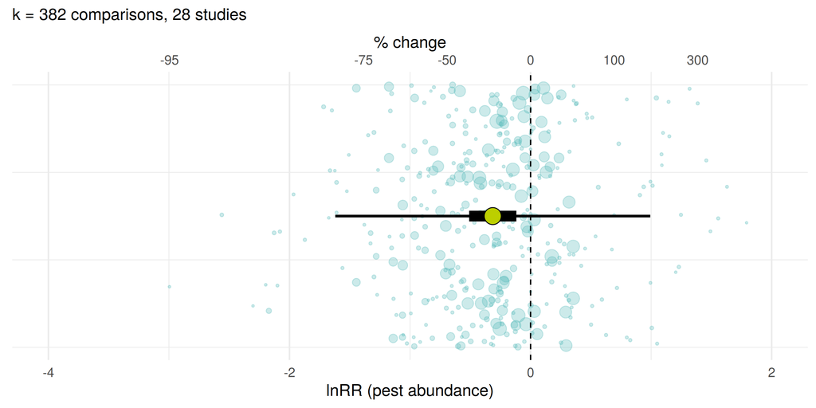

```r
pr_ml <- predict(m_ml)
set.seed(1)
ggplot(dat, aes(x = yi, y = 1)) +
  geom_jitter(aes(size = 1 / sqrt(vi)), height = 0.3, alpha = 0.3, colour = "#56B8B9") +
  annotate("segment", x = pr_ml$pi.lb, xend = pr_ml$pi.ub, y = 1, yend = 1, linewidth = 1) +
  annotate("segment", x = pr_ml$ci.lb, xend = pr_ml$ci.ub, y = 1, yend = 1, linewidth = 4) +
  annotate("point", x = pr_ml$pred, y = 1, size = 6, shape = 21, fill = "#BCCF00") +
  geom_vline(xintercept = 0, linetype = 2) +
  scale_size_continuous(range = c(0.5, 5), guide = "none") +
  scale_x_continuous(sec.axis = sec_axis(~ 100 * (exp(.) - 1), name = "% change",
                                         breaks = c(-95, -75, -50, 0, 100, 300))) +
  coord_cartesian(xlim = c(-4, 2)) +
  labs(x = "lnRR (pest abundance)", y = NULL,
       subtitle = paste0("k = ", nrow(dat), " comparisons, ", n_distinct(dat$study_id), " studies")) +
  theme_minimal(base_size = 13) +
  theme(axis.text.y = element_blank(), panel.grid.major.y = element_blank())
```

The `orchaRd` package (Nakagawa et al. 2021) draws these plots directly (`orchard_plot()`), including for moderators; it is installed from GitHub, so we build it by hand here.

**Answer**

```r
mean(dat$yi < pr_ml$pi.lb | dat$yi > pr_ml$pi.ub)
```

```
[1] 0.1151832
```

About 12% here — more than the naive 5%. The prediction interval is for **true** effects; observed values add their own sampling error on top, and a few studies are extreme. Worth a look: which studies are they?

# 6 Your turn: natural enemies

**Predict first**: will intercropping increase or decrease natural enemies?

Then go back to section 1, replace `grp <- "Pests"` by `grp <- "Natural enemies"`, and **rerun the script from the top**. Compare the multilevel estimate and prediction interval with those for pests.

**Solution**

```r
ne <- ic |>
  filter(functional_group == "Natural enemies", !sd_missing, !zero_mean) |>
  escalc(measure = "ROM", m1i = b_mean_t, sd1i = b_sd_t, n1i = b_n_t,
         m2i = b_mean_c, sd2i = b_sd_c, n2i = b_n_c, data = _)
m_ne <- rma.mv(yi, vi, random = ~ 1 | study_id / es_id, data = ne, test = "t", dfs = "contain")   # same as rerunning with grp <- "Natural enemies"
pr_ne <- predict(m_ne)
c(k = nrow(ne), studies = n_distinct(ne$study_id))
```

```
      k studies
    195      20
```

```r
pct(c(mean = pr_ne$pred, ci.lb = pr_ne$ci.lb, ci.ub = pr_ne$ci.ub, pi.lb = pr_ne$pi.lb, pi.ub = pr_ne$pi.ub))
```

```
 mean ci.lb ci.ub pi.lb pi.ub
  8.3  -9.1  29.0 -57.0 172.8
```

Natural enemies tend to be **more abundant** with intercropping, but the CI includes zero: the evidence is weaker than for pests. Comparing both groups properly requires a **meta-regression** (moderator = functional group): that is for the *Advanced methods* session.

# 7 Debrief and key messages

1. Weights follow precision; τ² tames very precise studies, the multilevel model stops studies with many rows from dominating.
2. Choose the model **a priori**: random effects, **multilevel** when studies give several effect sizes.
3. Report the mean **with** its CI, τ² and the **prediction interval**; add `robust()` as a safety net.
4. Show all the data: orchard plots.

**Next session (15:00):** are these 28 studies a representative sample — or is there publication bias?

## Going further in the online notebook

- [Dependence: map it before you model it](https://literaturesynthesis.github.io/notebook/chapters/dependence.html)
- [Combining effect sizes: fixed, random and multilevel models](https://literaturesynthesis.github.io/notebook/chapters/combining-effect-sizes.html)
- [One question from start to finish](https://literaturesynthesis.github.io/notebook/chapters/worked-example.html)

## 7.1 References

Nakagawa, S., M. Lagisz, R. E. O’Dea, J. Rutkowska, Y. Yang, D. W. A. Noble, and A. M. Senior. 2021. [The orchard plot: Cultivating a forest plot for use in ecology, evolution, and beyond](https://doi.org/10.1002/jrsm.1424). Research Synthesis Methods 12:4–12.

Nakagawa, S., and E. S. A. Santos. 2012. [Methodological issues and advances in biological meta-analysis](https://doi.org/10.1007/s10682-012-9555-5). Evolutionary Ecology 26:1253–1274.

Pustejovsky, J. E., and E. Tipton. 2022. [Meta-analysis with robust variance estimation: Expanding the range of working models](https://doi.org/10.1007/s11121-021-01246-3). Prevention Science 23:425–438.